# Run Python in RMarkdown

# Knitr setting for rmarkdown export

- library(reticulate)
- py_config: see current python version
- use_virtualenv(“py39bert”)
- Enable knit_engine to use python for rmarkdown export purpose
- knitr::knit_engines$set(python = reticulate::eng_python)

```
library(reticulate)
py_home <- py_config()
use_virtualenv(py_home$virtualenv)
knitr::knit_engines$set(python = reticulate::eng_python)
```

```r
library(reticulate)
py_home <- py_config()
use_virtualenv(py_home$virtualenv)
knitr::knit_engines$set(python = reticulate::eng_python)
```

# Install Python 3.9 on Ubuntu

1. Check Ubuntu version

   ```
   lsb_release -a
   ```

2. Update packages

   ```
   sudo apt update
   sudo apt -y upgrade
   ```

3. Install python 3.9

   ```
   sudo apt install python3.9
   python3 -V
   python3.9 -V
   ```

4. Install pip

   ```
   python3.9 -m pip install --upgrade pip
   ```

5. Install virtualenv

   ```
   pip3 install virtualenv
   which virtualenv
   ```

6. Create a virtualenv using Python 3.9 named as py39bert

   ```
   which python3.9
   virtualenv -p /usr/bin/python3.9 py39bert
   ```

7. Activate the virtualenv

   ```
   source ~/py39bert/bin/activate
   ```

8. Install ipython and jupyter notebook within virtualenv

   ```
   pip3 install ipython
   pip3 install jupyter notebook
   jupyter notebook to start jupyter notebook
   ```

9. Install python packages within the virtualenv

   ```
   pip3 install numpy
   ```

# Install Python packages within R

- Run python module within R

```r
library(reticulate)
py_home <- py_config()
use_virtualenv(py_home$virtualenv)
## virtualenv_install(py_home$virtualenv, "feather")

os <- import("os")
os$environ['HOME']
```

[1] “/home/ghowoo”

```r
os$listdir()[1:2]
```

[1] “flowchart.Rmd” “data_manipulation.Rmd”

# Install Python packages within Python

```python
import subprocess

def install(package):
    subprocess.check_call([sys.executable, "-m", "pip", "install", package])

# install("tabulate")
```

# Save Data in R

```r
library(feather)
library(data.table)
dt <- data.table(v1=1:6, v2=rep("A", 6))
write_feather(dt, "dt.feather")
list.files(pattern = "*.feather")
```

[1] “dt.feather”

# Read feather in Python

```python
import os
#print(os.getcwd())
path = os.getcwd()
os.chdir(path)
print(os.listdir()[0:4])
#print(os.getcwd())
```

[‘flowchart.Rmd’, ‘data_manipulation.Rmd’, ‘discretization.Rmd’, ‘graph.Rmd’]

```python
import pandas as pd
# import feather
path = "dt.feather"


df = pd.read_feather(path)

from tabulate import tabulate
print(tabulate(df, tablefmt='html'))
```

| 0 | 1 | A |
| --- | --- | --- |
| 1 | 2 | A |
| 2 | 3 | A |
| 3 | 4 | A |
| 4 | 5 | A |
| 5 | 6 | A |

# reticulate

- virtualenv_list() lists virtual environment
- use_virtualenv(“virtual-environment-name”): initiate python from virtual-environment, required = TRUE check if there is the version, otherwise may search for other versions
- use_python(“python path”): initiated python from path
- py_config() to see version

```r
## library(reticulate)


## Sys.setenv(RETICULATE_PYTHON = "/home/gongw/.virtualenvs/pybert/bin/python3.9")
## Sys.setenv(LD_LIBRARY_PATH = paste(
##              "/home/gongw/.virtualenvs/pybert/lib"
##            , Sys.getenv("LD_LIBRARY_PATH")
##            , sep = ":"))
## use_python("/home/gongw/.virtualenvs/pybert/bin/python3.9")

library(reticulate)
## use_python("/home/gongw/.virtualenvs/py39bert/bin/python3.9")
## use_python("/usr/bin/python3")

use_virtualenv("py39bert")

py_config()
py_discover_config()
## py_install()


## reticulate::py_config()


virtualenv_list()
## reticulate::use_python("/usr/bin/python3")
## use_virtualenv("py39bert", required = TRUE)
## py_available()

## reticulate::use_python("~/venv/pybert/bin/python3")

os <- import("os")
os$listdir(".")
sys <- import("sys")
sys$version


## py_install("pandas")
#py_install("pandas", method = "auto", conda = "auto")
```

# python matplotlib

```python
import sys
print(sys.version)
```

3.9.12 (main, Mar 24 2022, 16:20:11) [GCC 9.4.0]

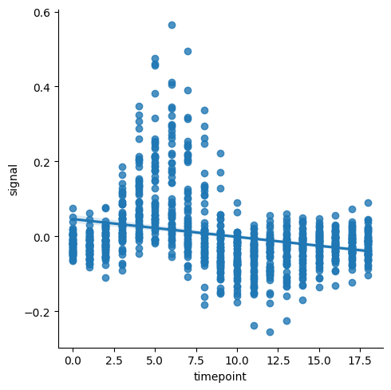

```python
import seaborn as sns
pr = sns.load_dataset("fmri")
import matplotlib as plt
sns.lmplot("timepoint", "signal", data = pr)
```

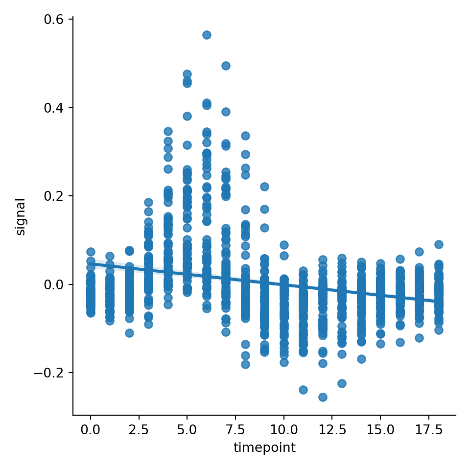

```python
plt.pyplot.show()
```

# Python print table

```python
x = 'hello, python world!'
print(x)
```

hello, python world!

```python
import numpy as np
# a = np.arange(5)

table = [['one','two','three'],['four','five','six'],['seven','eight','nine']]
from tabulate import tabulate
print(tabulate(table, tablefmt = 'html', headers = ["Column I", "Column II", "Column III"]))
```

| Column I | Column II | Column III |
| --- | --- | --- |
| one | two | three |
| four | five | six |
| seven | eight | nine |

# Save Python plot

- To show plot in rmarkdown

  ```
  ![matplot](pythton_pyplot.png)
  ```

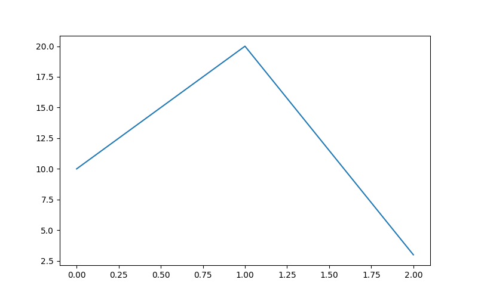

matplot

```python
import matplotlib.pyplot as plt
fig, ax = plt.subplots( nrows=1, ncols=1 )
ax.plot([0,1,2], [10,20,3])
#ax.show()
# plt.plot([1,2,3],[3,4,5])
# plt.show()

fig.savefig("pythton_pyplot.png")
plt.close(fig)
```

# Python Version

```python
import sys
print(sys.version_info)
```

sys.version_info(major=3, minor=9, micro=12, releaselevel=‘final’, serial=0)

R version 4.1.2 (2021-11-01) Platform: x86_64-pc-linux-gnu (64-bit) Running under: Ubuntu 20.04.3 LTS

Matrix products: default BLAS: /usr/lib/x86_64-linux-gnu/blas/libblas.so.3.9.0 LAPACK: /usr/lib/x86_64-linux-gnu/lapack/liblapack.so.3.9.0

locale: [1] LC_CTYPE=C.UTF-8 LC_NUMERIC=C LC_TIME=C.UTF-8  
[4] LC_COLLATE=C.UTF-8 LC_MONETARY=C.UTF-8 LC_MESSAGES=C.UTF-8  
[7] LC_PAPER=C.UTF-8 LC_NAME=C LC_ADDRESS=C  
[10] LC_TELEPHONE=C LC_MEASUREMENT=C.UTF-8 LC_IDENTIFICATION=C

attached base packages: [1] stats graphics grDevices utils datasets methods base

other attached packages: [1] feather_0.3.5 reticulate_1.24 Wu_0.0.0.9000  
[4] flexdashboard_0.5.2 lme4_1.1-27.1 Matrix_1.4-0  
[7] mgcv_1.8-38 nlme_3.1-152 png_0.1-7  
[10] scales_1.1.1 nnet_7.3-16 labelled_2.8.0  
[13] kableExtra_1.3.4 plotly_4.9.4.1 gridExtra_2.3  
[16] ggplot2_3.3.5 DT_0.18 tableone_0.13.0  
[19] magrittr_2.0.1 lubridate_1.7.10 dplyr_1.0.7  
[22] plyr_1.8.6 data.table_1.14.0 rmdformats_1.0.2  
[25] knitr_1.36